# Conceptos básicos de Python

#### © **[Jorge Ramírez](http://blogs.upm.es/compsoftmatter/)**, **[Universidad Politécnica de Madrid](http://www.upm.es)**, 2019

Este documento es una introducción a conceptos básicos de Python y Jupyter Labs para estudiantes que nunca han utilizado estas herramientas.

## ¿Cómo utilizar Python?

Python se puede utilizar de muchas formas diferentes. Aquí destacamos 3 muy típicas.

### De forma interactiva

Abrimos una ventana del interprete de python y empezamos a introducir comandos uno a uno.

[figure not shown]

### Ejecutando programas escritos en Python

Se pueden guardar secuencias de instrucciones en ficheros de texto y ejecutarlas como si fuera un programa.

[figure not shown]

### Utilizando Jupyter Labs

**[Jupyter Labs](https://Jupyter.org)** es una aplicación web que permite crear y compartir documentos que combinan texto, imágenes, ecuaciones, gráficos y código que se puede ejecutar de forma interactiva. Este tutorial se va a desarrollar por completo mediante esta herramienta.

[figure not shown]

## Python es una calculadora básica

De forma similar a **[Matlab](https://es.mathworks.com/?s_tid=gn_logo)** u **[Octave](https://www.gnu.org/software/octave/)**, Python puede ser utilizado como una calculadora elemental. La notación de los operadores y el orden en que se aplican las operaciones se muestran en la siguiente tabla:

[figure not shown]

| Operación | Operador | Ejemplo |
| --- | --- | --- |
| Exponente | ** | 2**3=8 |
| Multiplicación | * | 4 * 2.5=10 |
| División | / | 9.9/3=3.3 |
| División Entera | // | 9//2=4 |
| Resto (módulo) | % | 9%2=1 |
| Suma | + | 3+5.1=8.1 |
| Resta | - | 65.3-2=63.3 |

```python
x=3
y=5
x**y+2
```

```
245
```

[figure not shown]

Si necesitamos **funciones matemáticas**, es necesario **importar la librería** *numpy* (que se comenta en detalle más adelante). Las funciones más típicas (sin, cos, exp, etc) están disponibles ([lista completa de todas las funciones incluidas en numpy](https://docs.scipy.org/doc/numpy/reference/routines.math.html)).

Existen varias formas de importar una librería en python:

- Con el comando **import**. Para acceder al as variables y funciones de la librería, tendrémos que anteponer el nombre de la librería como prefijo, seguido de un punto.

```python
import numpy
numpy.exp(3.4)
```

```
29.96410004739701
```

- Mediante el comando **from** * **import** *, se pueden importar funciones específicas o todas las funciones de una librería.

```python
from numpy import exp, sin, tan
print(tan(435.3))
from numpy import *
print(cos(434.5))
```

```
-5.216053166299225
0.5733448260327263
```

- Importando la librería con un **alias** (para evitar conflicto con otras funciones de otras librerías).

```python
import numpy as np
import math as mt
print(np.sin(4.2))
print(mt.sin(4.2))
```

```
-0.8715757724135882
-0.8715757724135882
```

[figure not shown]

## Python como lenguaje de programación

Funciones, bucles, instrucciones condicionales

[figure not shown]

### Bucles e instrucciones condicionales

Podemos hacer bucles (*loops*) para hacer cálculos y *print* para mostrar el resultado final. En python, el **espacio** es **muy importante**. Para delimitar el contenido de un bucle, no se utilizan llaves, ni paréntesis, ni palabras clave tipo *begin* o *end*. El espacio deja claro dónde comienza y donde termina un bucle.

```python
result=0
for i in range(1,10):
    print(i, end=' ')
    result+=i
print("\nLA SUMA ES: {:7d}".format(result))

result=0
for i in range(1,10):
    if (i%2==0):
        print(i, end=' ')
        result+=i
print("\nRESULT IS: {:7d}".format(result))
```

```
1 2 3 4 5 6 7 8 9
LA SUMA ES:      45
2 4 6 8
RESULT IS:      20
```

[figure not shown]

### Subrutinas y funciones

Como en cualquier otro lenguaje de programación, podemos declarar funciones y utilizarlas más adelante en nuestro código. Esto nos permite crear una librería de funciones especializadas que podemos utilizar posteriormente. Recordar que:

- Las funciones se definen con la palabra clave **def**.
- Los argumentos de la función se especifican entre paréntesis.
- Igual que con los bucles, el contenido de la función se delimita mediante el **espacio**.

```python
def fact(x):
    if not isinstance(x, (int)) or (x<0):
        return 0
    if x==0:
        return 1
    else:
        return x*fact(x-1)

fact(5)
```

```
120
```

[figure not shown]

## Elementos característicos del lenguaje Python

Listas y Diccionarios para organizar los datos.

[figure not shown]

### Listas

Las listas son una forma versatil de almacenar la información. Son formalmente similares a los *arrays* de **Matlab** u otros lenguajes de programación, pero son mucho más flexibles.

- Las listas se definen separando los elementos con comas y encerrándolos entre corchetes [...]
- Para acceder a los elementos de una lista, también se utilizan los corchetes.
- Los índices empiezan en 0

```python
x = [1, 2, 4, 8]
print(x)
print(x[0])
print(x[3])
print(len(x))
x.append(16)
print(x)
len(x)
```

```
[1, 2, 4, 8]
1
8
4
[1, 2, 4, 8, 16]
```

```
5
```

#### Operaciones con listas:

- Añadir elementos al final (*append*)
- Eliminar un elemento de la lista (*pop*)
- concatenación (+)

```python
x=[1,2,4,8,16]
print(x)
x.append(32)
print(x)
x.pop(0)
print(x)
x=x+x
print(x)
```

```
[1, 2, 4, 8, 16]
[1, 2, 4, 8, 16, 32]
[2, 4, 8, 16, 32]
[2, 4, 8, 16, 32, 2, 4, 8, 16, 32]
```

#### Operaciones avanzadas con listas:

- Recorrer una lista (LOOP)
- Crear listas complejas en una sola línea (**list comprehension**)

```python
x=[np.random.random() for i in range(0,10)]
for val in x:
    print(val, np.sin(val))
```

```
0.29192670550711974 0.2877979469597556
0.34854780462430324 0.34153329366164137
0.03311417191015853 0.0331081203600246
0.3464628174709782 0.3395729365279446
0.36096603472430566 0.3531781775892965
0.37197871370950897 0.3634595317439747
0.627951776816482 0.5874885026290433
0.61375293044433 0.5759395006120647
0.4358869656085832 0.4222145980367013
0.6617992428828704 0.6145372466929286
```

- Numpy puede operar directamente con todos los elementos de una lista

```python
print(x)
print(np.sin(x))
```

```
[0.29192670550711974, 0.34854780462430324, 0.03311417191015853, 0.3464628174709782, 0.36096603472430566, 0.37197871370950897, 0.627951776816482, 0.61375293044433, 0.4358869656085832, 0.6617992428828704]
[0.28779795 0.34153329 0.03310812 0.33957294 0.35317818 0.36345953
 0.5874885  0.5759395  0.4222146  0.61453725]
```

[figure not shown]

### Diccionarios

Los diccionarios son útiles para almacenar información en términos de una *clave* (palabra o secuencia de letras).

Los diccionarios se especifican como una secuencia separada por comas de etiquetas sus correspondientes valores, separados estos por dos puntos. La secuencia completa se delimita mediante llaves.

Por ejemplo, podríamos almacenar las masas atómicas de molécular sencillas:

```python
MW={'H2O': 18.02, 'CO2': 44.01, 'C2H6': 30.07}
```

Podemos acceder a cualquiera de los elementos del diccionario fácilmente utilizando su clave:

```python
MW['C2H6']
```

```
30.07
```

#### Operaciones avanzadas con diccionarios:

- Se pueden recorrer mediante un LOOP
- Se pueden ordenar por clave
- Se pueden ordenar por valor

```python
for mol in MW.keys():
    print("The molar mass of {:s} is {:6.2f}".format(mol, MW[mol]))
print("")
for mol in sorted(MW):
    print("The molar mass of {:s} is {:6.2f}".format(mol, MW[mol]))
print("")
for mol in sorted(MW, key=MW.get):
    print("The molar mass of {:s} is {:6.2f}".format(mol, MW[mol]))
```

```
The molar mass of H2O is  18.02
The molar mass of CO2 is  44.01
The molar mass of C2H6 is  30.07

The molar mass of C2H6 is  30.07
The molar mass of CO2 is  44.01
The molar mass of H2O is  18.02

The molar mass of H2O is  18.02
The molar mass of C2H6 is  30.07
The molar mass of CO2 is  44.01
```

[figure not shown]

## Álgebra lineal con numpy

El *matlab* de python.

[figure not shown]

### Declaración y manipulación de vectores y matrices

La librería [numpy](https://www.numpy.org/) nos permite manipular vectores y matrices y resolver problemas de álgebra lineal (entre otras cosas). Por ejemplo, podemos declarar un vector y acceder y mostrar sus elementos de la forma habitual:

```python
import numpy as np
a=np.zeros(10)
print(a)
a[4]=3.5
print(a)
```

```
[0. 0. 0. 0. 0. 0. 0. 0. 0. 0.]
[0.  0.  0.  0.  3.5 0.  0.  0.  0.  0. ]
```

O podemos declarar una matriz:

```python
A=np.zeros((4,4))
print(A)
A[0,2]=4.2
A[2,1]=8.4
print(A)
```

```
[[0. 0. 0. 0.]
 [0. 0. 0. 0.]
 [0. 0. 0. 0.]
 [0. 0. 0. 0.]]
[[0.  0.  4.2 0. ]
 [0.  0.  0.  0. ]
 [0.  8.4 0.  0. ]
 [0.  0.  0.  0. ]]
```

### Resolución de sistemas lineales

Es facil generar una matriz y un vector de números aleatorios con numpy:

```python
A=np.random.rand(3,3)
b=np.random.rand(3)
print(A)
print(b)
```

```
[[0.23705762 0.91541247 0.49435888]
 [0.35045794 0.02928186 0.78442506]
 [0.80194717 0.19661175 0.93540643]]
[0.36253573 0.93951335 0.70009506]
```

Podemos resolver un sistema de ecuaciones como el siguiente fácilmente $$ Ax=b $$

```python
x=np.linalg.solve(A,b)
print(x)
```

```
[-0.99409862 -0.23798813  1.65072727]
```

Podemos comprobar que la solución es correcta:

```python
print(b)
np.dot(A,x)
```

```
[0.36253573 0.93951335 0.70009506]
```

```
array([0.36253573, 0.93951335, 0.70009506])
```

[figure not shown]

## Representación de gráficos con matplotlib

Con la librería [matplotlib](https://matplotlib.org/) podemos representar gráficamente nuestros resultados numéricos:

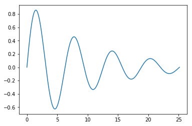

```python
#%matplotlib widget
%matplotlib inline
import matplotlib.pyplot as plt
x=np.linspace(0,8*np.pi,200)
y=np.sin(x)*np.exp(-x/10.0)
plt.plot(x,y)
```

Se pueden manipular todas las opciones del gráfico, al igual que con Matlab:

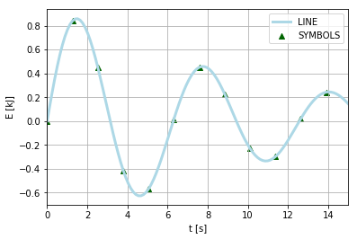

```python
plt.figure(2)
plt.plot(x,y, color='lightblue', linewidth=3, label="LINE")
plt.scatter(x[0:200:10], y[0:200:10], color='darkgreen', marker='^', label="SYMBOLS")
plt.xlim(0., 15.0)
plt.xlabel("t [s]")
plt.ylabel("E [kJ]")
plt.grid()
plt.legend()
plt.show()
```

Incluso se pueden generar gráficos con más de un subgráfico en su interior

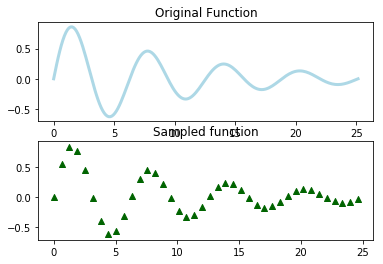

```python
plt.figure(3)
plt.subplot(2,1,1)
plt.plot(x,y, color='lightblue', linewidth=3, label="LINE")
plt.title('Original Function')

plt.subplot(2,1,2)
plt.scatter(x[0:200:5], y[0:200:5], color='darkgreen', marker='^', label="SYMBOLS")
plt.title('Sampled function')
```

Incluso se pueden hacer representaciones tridimensionales

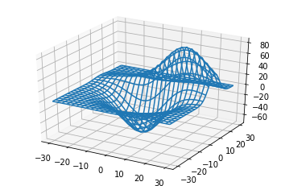

```python
from mpl_toolkits.mplot3d import axes3d

fig = plt.figure()
ax = fig.add_subplot(111, projection='3d')

# Grab some test data.
X, Y, Z = axes3d.get_test_data(0.05)

# Plot a basic wireframe.
ax.plot_wireframe(X, Y, Z, rstride=5, cstride=5)

plt.show()
```

[figure not shown]

## Resolviendo ecuaciones diferenciales con Scipy

El *matlab* de python (junto con numpy).

### Una ecuación diferencial ordinaria

- **modelo**: La función que devuelve el valor de la derivada en términos de los valores actuales de y
- **y0**: La condición inicial
- **t**: Los instantes de tiempo en los que queremos determinar la solución.

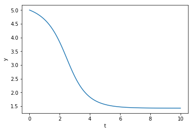

```python
%matplotlib inline
from scipy.integrate import odeint
def modelo(y, t):
    return -0.1*y+np.cos(y)

y0 = 5
t = np.linspace(0,10,100)
y = odeint(modelo, y0, t)
plt.plot(t,y)
plt.xlabel("t")
plt.ylabel("y")
```

[figure not shown]

### Interactuando con el código

Podemos resolver el mismo problema, pero en función de un ciertos parámetros $k$ y $c$. $$ \frac{dy}{dt}=- k y + sin(c y)$$

[figure not shown]

### Un sistema de ecuaciones diferenciales acopladas

$$ \frac{dx}{dt} = Ax + By $$$$ \frac{dy}{dt} = Cx + Dy $$

Con condiciones iniciales: $$ x(0)=x_0 $$ $$ y(0)=y_0 $$

[figure not shown]

## Para Finalizar... Las Ecuaciones Diferenciales de Lorentz

Para finalizar, vamos a explorar el sistema de ecuaciones diferenciales de Lorentz:

$$ \begin{aligned} \dot{x} & = \sigma(y-x) \\ \dot{y} & = \rho x - y - xz \\ \dot{z} & = -\beta z + xy \end{aligned} $$

[figure not shown]

Podemos explorar la forma de la solución modificando los valores de los parámetros $\sigma$, $\beta$ y $\rho$ de forma interactiva (el fichero *lorenz.py* contiene la subrutina que resuelve la ecuación diferencial):

[figure not shown]

## Matemáticas simbólicas con Sympy

[Sympy](https://www.sympy.org/en/index.html) es una librería de Python para hacer cálculos con matemática simbólica (de forma parecida a **[Maple](https://www.maplesoft.com/)** o **[Mathematica](https://www.wolfram.com/mathematica/)**). En esta librería, antes de poder operar con símbolos algebraicos, tenemos que definirlos. Los símbolos se pueden definir uno a uno o como listas. Para simplificar el uso, es importante asignar los simbolos a una variable que se llame igual que el símbolo en cuestión:

```python
from sympy import *
x=symbols('x')
v, y, z = symbols('v y z')
sin(x+1)*z**y/v
```

$\displaystyle \frac{z^{y} \sin{\left(x + 1 \right)}}{v}$

Algunas de las operaciones que podemos hacer con Sympy son:

- Simplificaciones
- Expansiones
- Sustituciones

```python
print('Ejemplo de expand')
a=(x+1)**2
pretty_print(a)
a=expand(a)
pretty_print(a)
print('Ejemplo de simplify')
a=(x**2+2*x+1)/(x+1)
pretty_print(a)
a=simplify(a)
pretty_print(a)
print('Ejemplo de substitute')
a=x+y**2
pretty_print(a)
a.subs(y,x)
```

```
Ejemplo de expand
       2
(x + 1)
 2
x  + 2⋅x + 1
Ejemplo de simplify
 2
x  + 2⋅x + 1
────────────
   x + 1
x + 1
Ejemplo de substitute
     2
x + y
```

$\displaystyle x^{2} + x$

También podemos hacer operaciones de cálculo más complejas, como:

- Límites
- Derivadas
- Integrales
- Expansión en series de Taylor

```python
pretty_print(limit(sin(x)/x, x, 0))
pretty_print(limit(1-exp(-x),x,oo))
pretty_print(diff(sin(x*2)*cos(x), x))
pretty_print(integrate(x**2*sin(x),x))
pretty_print(series(cos(x),x,0,10))
```

```
1
1
-sin(x)⋅sin(2⋅x) + 2⋅cos(x)⋅cos(2⋅x)
   2
- x ⋅cos(x) + 2⋅x⋅sin(x) + 2⋅cos(x)
     2    4     6      8
    x    x     x      x      ⎛ 10⎞
1 - ── + ── - ─── + ───── + O⎝x  ⎠
    2    24   720   40320
```

[figure not shown]

## Leyendo ficheros de datos con pandas

La librería [pandas](https://pandas.pydata.org/) utiliza unos objetos denominados *dataframes* que se pueden leer desde un fichero CSV o Excel.

Leyendo un fichero CSV:

```python
%matplotlib inline
import pandas as pd
df=pd.read_csv("Excel_Data_CSV.csv")
df.tail()
```

|  | X | Y |
| --- | --- | --- |
| 189 | 1.89 | 0.090643 |
| 190 | 1.90 | 0.089741 |
| 191 | 1.91 | 0.088848 |
| 192 | 1.92 | 0.087964 |
| 193 | 1.93 | 0.087089 |

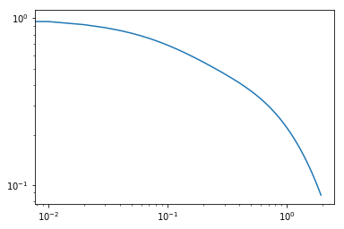

```python
plt.loglog(df.X, df.Y)
```

Leyendo un fichero Excel:

```python
df2=pd.read_excel("Excel_Data.xlsx")
df.tail()
```

|  | X | Y |
| --- | --- | --- |
| 189 | 1.89 | 0.090643 |
| 190 | 1.90 | 0.089741 |
| 191 | 1.91 | 0.088848 |
| 192 | 1.92 | 0.087964 |
| 193 | 1.93 | 0.087089 |

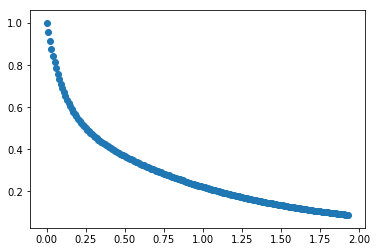

```python
%matplotlib inline
plt.scatter(df["X"],df["Y"])
```

## Bibliografía - Otros recursos

- [Tutorial](https://www.learnpython.org/) básico en learnpython.org.
- [Curso](https://www.udemy.com/complete-python-bootcamp/?siteID=jU79Zysihs4-wy57L5rBsHZNKZ2IjcYiTg&LSNPUBID=jU79Zysihs4) completo en Udemy.
- Tutorial de [Numpy](https://docs.scipy.org/doc/numpy/user/quickstart.html)
- Tutorial de [Scipy](https://docs.scipy.org/doc/scipy/reference/tutorial/index.html)
- Tutorial de [Matplotlib](https://matplotlib.org/tutorials/introductory/pyplot.html)
- Tutorial de [Sympy](https://docs.sympy.org/latest/tutorial/index.html)
- Tutorial de [Pandas](https://pandas.pydata.org/pandas-docs/stable/getting_started/tutorials.html)